# MY457/MY557: Causal Inference for Experimental and Observational Studies

Class 4: Instrumental Variables

```r
library(dplyr)
library(ggplot2)
library(AER)
```

# In-class exercise: Implementing intrumental variables estimation

In this exercise we try different ways of calculating the basic instrumental variables estimator. This is mainly for demonstration purposes. In practice, it is best to use the `ivreg` function, because it also implements the standard errors correctly. At first, let’s start with creating a dataset.

```r
# SIMULATE DATA

# PARAMETERS
N <- 10000
U <- rnorm(N, mean = 5, sd = 3)
b0 <- 2
b1 <- 1.5

# POTENTIAL OUTCOMES
y0 <- b0 + b1 * U + rnorm(N)
y1 <- y0 + mean(y0) + rnorm(N)
y1[which(y0 < median(y0))] <- y1[which(y0 < median(y0))] / 2

# CREATE DATAFRAME
df <- cbind(y0, y1, U) %>% as_tibble()

# GENERATE TYPES OF COMPLIANCE
type <- rep(NA, 10000)
type[which(y1 > median(y1))] <-
  sample(c(rep('Complier', 3500), rep('Always Taker', 1000), rep('Never Taker', 500)))
type[which(y1 < median(y1))] <-
  sample(c(rep('Complier', 1500), rep('Always Taker', 1500), rep('Never Taker', 2000)))
df$type <- type

# CREATE INSTRUMENT
df$z <- sample(c(rep(0, 5000), rep(1, 5000)))

# CREATE TREATMENT ASSIGNMENT
df <- df %>%
  mutate(d = case_when(type == 'Always Taker' ~ 1,
                       type == 'Never Taker' ~ 0,
                       (type == 'Complier' & z == 0) ~ 0,
                       (type == 'Complier' & z == 1) ~ 1))

# REAL OUTCOMES
df <- df %>% mutate(y = case_when(d == 0 ~ y0, d == 1 ~ y1))
```

Before we estimate the treatment effect via the instrumental variable Z, let’s use the potential outcomes to calculate the average treatment effects.

```r
# TRUE ATE
true_ate <- t.test(df$y1, df$y0, paired = TRUE)
true_ate
```

```
##
##  Paired t-test
##
## data:  df$y1 and df$y0
## t = 140.66, df = 9999, p-value < 2.2e-16
## alternative hypothesis: true difference in means is not equal to 0
## 95 percent confidence interval:
##  5.612333 5.770963
## sample estimates:
## mean of the differences
##                5.691648
```

In contrast, the naive approach would be if we just regress the observed outcome on the treatment assignment indicator.

```r
# NAIVE "ATE"
naive_ate <- lm(y ~ d, data = df)

true_ate
```

```
##
##  Paired t-test
##
## data:  df$y1 and df$y0
## t = 140.66, df = 9999, p-value < 2.2e-16
## alternative hypothesis: true difference in means is not equal to 0
## 95 percent confidence interval:
##  5.612333 5.770963
## sample estimates:
## mean of the differences
##                5.691648
```

```r
summary(naive_ate)
```

```
##
## Call:
## lm(formula = y ~ d, data = df)
##
## Residuals:
##      Min       1Q   Median       3Q      Max
## -15.9329  -6.4319   0.4503   5.1256  19.7971
##
## Coefficients:
##             Estimate Std. Error t value Pr(>|t|)
## (Intercept)  9.11532    0.09128   99.86   <2e-16 ***
## d            6.92826    0.12932   53.58   <2e-16 ***
## ---
## Signif. codes:  0 '***' 0.001 '**' 0.01 '*' 0.05 '.' 0.1 ' ' 1
##
## Residual standard error: 6.466 on 9998 degrees of freedom
## Multiple R-squared:  0.2231, Adjusted R-squared:  0.223
## F-statistic:  2870 on 1 and 9998 DF,  p-value: < 2.2e-16
```

Now, because we do not observe both potential outcomes, we need a different strategy. In the following, we will the instrumental variable approach to get a local average treatment effect (LATE). There are basically three different estimates we need to understand: (i) the effect of Z on Y (the intention-to-treat, ITT), (ii) the effect of Z on D (estimated proportion of compliers), (iii) the Wald estimate.

```r
# 1. Effect of Z on Y
mean(df$y[df$z==1])-mean(df$y[df$z==0])
```

```
## [1] 3.571112
```

```r
y.on.z <- lm(y ~ z, data = df)
summary(y.on.z)
```

```
##
## Call:
## lm(formula = y ~ z, data = df)
##
## Residuals:
##     Min      1Q  Median      3Q     Max
## -20.394  -5.819  -1.405   5.969  25.059
##
## Coefficients:
##             Estimate Std. Error t value Pr(>|t|)
## (Intercept)  10.7814     0.1006   107.2   <2e-16 ***
## z             3.5711     0.1423    25.1   <2e-16 ***
## ---
## Signif. codes:  0 '***' 0.001 '**' 0.01 '*' 0.05 '.' 0.1 ' ' 1
##
## Residual standard error: 7.115 on 9998 degrees of freedom
## Multiple R-squared:  0.05926,    Adjusted R-squared:  0.05917
## F-statistic: 629.8 on 1 and 9998 DF,  p-value: < 2.2e-16
```

```r
itt_est <- coef(y.on.z)[2]

###

# 2. Effect of Z on D
mean(df$d[df$z==1])-mean(df$d[df$z==0])
```

```
## [1] 0.4856
```

```r
d.on.z <- lm(d ~ z, data = df)
summary(d.on.z)
```

```
##
## Call:
## lm(formula = d ~ z, data = df)
##
## Residuals:
##     Min      1Q  Median      3Q     Max
## -0.7410 -0.2554 -0.2554  0.2590  0.7446
##
## Coefficients:
##             Estimate Std. Error t value Pr(>|t|)
## (Intercept) 0.255400   0.006182   41.31   <2e-16 ***
## z           0.485600   0.008743   55.54   <2e-16 ***
## ---
## Signif. codes:  0 '***' 0.001 '**' 0.01 '*' 0.05 '.' 0.1 ' ' 1
##
## Residual standard error: 0.4371 on 9998 degrees of freedom
## Multiple R-squared:  0.2358, Adjusted R-squared:  0.2357
## F-statistic:  3085 on 1 and 9998 DF,  p-value: < 2.2e-16
```

```r
prop_compliers <- coef(d.on.z)[2]

###

# 3. WALD ESTIMATE
itt_est/prop_compliers
```

```
##        z
## 7.354021
```

However, you can also get the same number from the two-stage least squares (2SLS), (i) with the base-R lm function, or (ii) with the ivreg function.

```r
# 2SLS using lm
df$d_hat <- predict(d.on.z)
iv_2sls_2 <- lm(y ~ d_hat, data = df)
summary(iv_2sls_2)
```

```
##
## Call:
## lm(formula = y ~ d_hat, data = df)
##
## Residuals:
##     Min      1Q  Median      3Q     Max
## -20.394  -5.819  -1.405   5.969  25.059
##
## Coefficients:
##             Estimate Std. Error t value Pr(>|t|)
## (Intercept)   8.9032     0.1624   54.82   <2e-16 ***
## d_hat         7.3540     0.2930   25.10   <2e-16 ***
## ---
## Signif. codes:  0 '***' 0.001 '**' 0.01 '*' 0.05 '.' 0.1 ' ' 1
##
## Residual standard error: 7.115 on 9998 degrees of freedom
## Multiple R-squared:  0.05926,    Adjusted R-squared:  0.05917
## F-statistic: 629.8 on 1 and 9998 DF,  p-value: < 2.2e-16
```

```r
# 2SLS using ivreg
iv_2sls <- ivreg(y ~ d | z, data = df)
summary(iv_2sls)
```

```
##
## Call:
## ivreg(formula = y ~ d | z, data = df)
##
## Residuals:
##      Min       1Q   Median       3Q      Max
## -15.7208  -6.4881   0.6568   5.0815  19.5834
##
## Coefficients:
##             Estimate Std. Error t value Pr(>|t|)
## (Intercept)   8.9032     0.1477   60.29   <2e-16 ***
## d             7.3540     0.2664   27.60   <2e-16 ***
## ---
## Signif. codes:  0 '***' 0.001 '**' 0.01 '*' 0.05 '.' 0.1 ' ' 1
##
## Residual standard error: 6.469 on 9998 degrees of freedom
## Multiple R-Squared: 0.2222,  Adjusted R-squared: 0.2221
## Wald test: 761.8 on 1 and 9998 DF,  p-value: < 2.2e-16
```

Further, we can briefly examine the distribution of the true individual-level treatment effects according to type and treatment status.

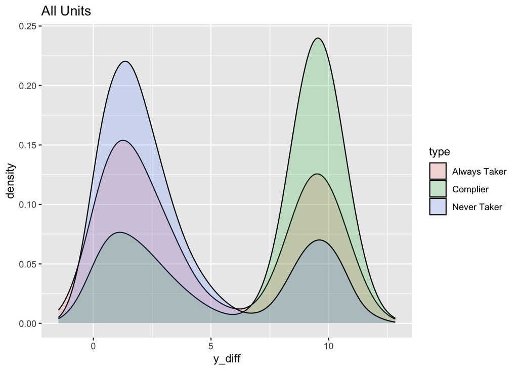

```r
df <- df %>% mutate(y_diff = y1 - y0)
p1 <- ggplot(data = df, aes(x = y_diff, fill = type)) +
  geom_density(alpha = 0.2) + ggtitle("All Units")
p1
```

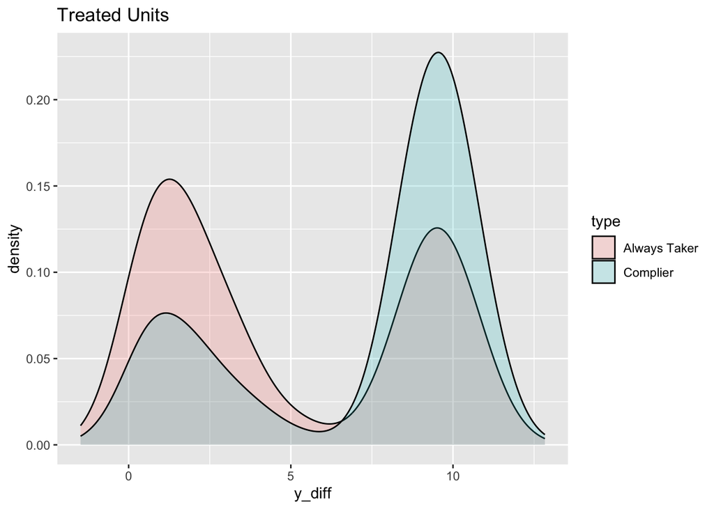

```r
p2 <- ggplot(data = df[df$d == 1, ], aes(x = y_diff, fill = type)) +
  geom_density(alpha = 0.2) + ggtitle("Treated Units")
p2
```

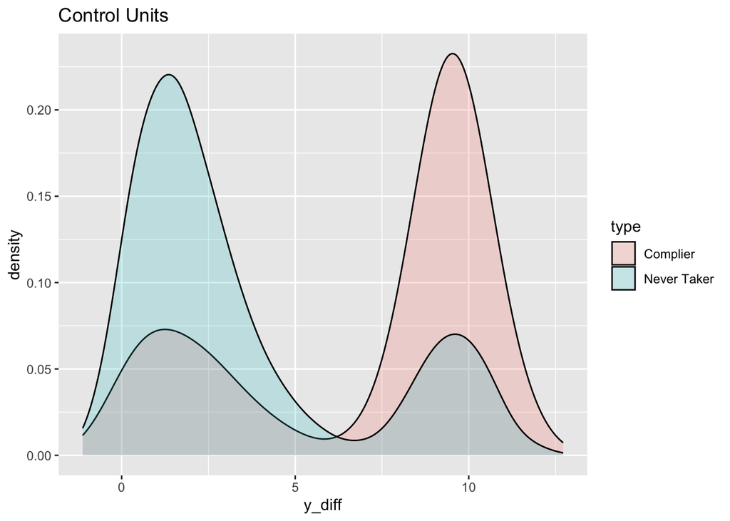

```r
p3 <- ggplot(data = df[df$d == 0, ], aes(x = y_diff, fill = type)) +
  geom_density(alpha = 0.2) + ggtitle("Control Units")
p3
```

The plots indicate that being a complier is associated with taking on relatively high values of the $Y_{1}$ potential outcome and therefore relatively high values of the true treatment effect. The bimodal distributions indicate that substantial proportions of each type take on both relatively low and relatively high values of the treatment effect, but clearly one side or the other dominates.